# Simulate learner/teacher pair

Andrew Perfors

Let’s begin by loading up the pre-calculated files so we are more resource friendly and can do everything a lot faster.

# What do we have?

*xrange*: the x-axis range for our hypothesis space: 0, 1, 2, 3, 4, 5, 6, 7, 8, 9, 10

*yrange*: the y-axis range for our hypothesis space: 0, 1, 2, 3, 4, 5, 6, 7, 8, 9, 10

*alphas*: the values of alpha I precalculated: -5, -2, -1, -0.5, -0.1, 0, 0.1, 0.5, 1, 2, 5

*hyp*: all possible hypotheses in this space: there are *nHyp* = 3025

*pts*: all of the points in this space: there are *nPts* = 100

*posProbPts*: a 3d array of size *nPts* x *nHyp* x *length(alphas)*. This calculating the probability of generating each point assuming it is positive given each hypothesis and each alpha. This is all possible likelihoods (for the positive observations) we need to know.

*negProbPts*: a 3d array of size *nPts* x *nHyp* x *length(alphas)*. This calculating the probability of generating each point assuming it is negative given each hypothesis and each alpha. This is all possible likelihoods (for the negative observations) we need to know.

*allProbPts*: a 3d array of size *nPts* x *nHyp* x *length(alphas)*. This calculating the probability of generating each point whether it is positive or negative (i.e. with both of those summed together), given each hypothesis and each alpha. This is all possible likelihoods (for both positive and negative observations) we need to know.

*consPts*: a 2d array of size *nPts* x *nHyp*. For each point and hypothesis, this is TRUE if that point is contained within that hypothesis and FALSE otherwise. Useful as a quick lookup.

## The true hypothesis

Let’s randomly generate a single **true rectangle**. We can control whether it is small, medium, or large using the parameter above.

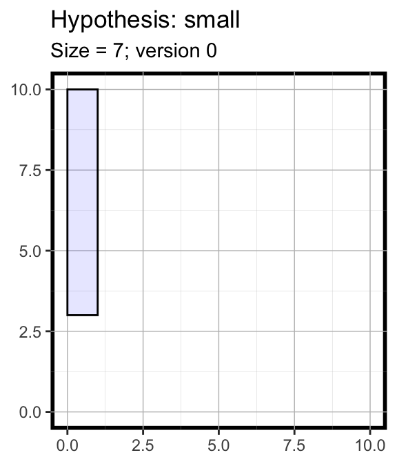

# Let’s make a learner/teacher pairs. Each pair contains the following:

**trueH**: coordinates of the true hypothesis the teacher knows (x1,y1,x2,y2). Already generated

**lnAlpha**: the alpha value that the learner assumes the teacher has. Here it is 0

**lnPts**: the set of points tracked by the learner. Each row is a point. The columns are: *x* (the x coordinate of that point); *y* (the y coordinate of that point); *selected* (TRUE if the teacher has provided that point; initialised to FALSE); *type* (“positive” or “negative”, initialised to NA since no points have been seen at the start); *prior* (the prior probability of each point, initialised to be uniform); and *posterior* (posterior probability of each point, initialised to be uniform). As the learner sees new points, they update *selected*, *type*, and *posterior*.

**lnHyp**: the set of hypotheses tracked by the learner. Each row is a hypothesis. The columns are: *x1,y1,x2,y2* (the coordinates of that hypothesis) *size* (the size of that hypothesis); *negSize* (the size of the space around the hypothesis); *prior* (their priors over hypotheses, initialised to be uniform); *nPos* and *nNeg* (the number of positive and negative points seen so far; initialised to zero); *consPos* and *consNeg* (TRUE if the positive/negative points seen so far are all consistent with that hypothesis; initialised to TRUE because none have been seen so far); *likePos* and *likeNeg* (the probability of having seen those positive/negative datapoints given that hypothesis. zero if they are not consistent); *posterior* (posterior probability of that hypothesis, based on combining the prior with likePos and likeNeg). As the learner sees new points, they update everything after the *prior* column.

**tchAlpha**: the alpha value that the teacher has. Here it is 1

**tchLnAlpha**: the alpha value the teacher assumes the learner has about them. Here it is 1

**tchPts**: the set of points tracked by the teacher that it is assuming the learner has. Each row is a point. The columns are: *x* (the x coordinate of that point); *y* (the y coordinate of that point); *selected* (TRUE if the teacher has provided that point; initialised to FALSE); *type* (“positive” or “negative”, initialised to NA since no points have been seen at the start); *prior* (the prior probability of each point, initialised to be uniform); and *posterior* (posterior probability of each point, initialised to be uniform). As the teacher provides new points, they update *selected*, *type*, and *posterior*. Note that their values might be different than the learner’s in *lnPts* if they are wrong about what the learner’s assumed alpha is.

**tchHyp**: the set of hypotheses the teacher is assuming the learner has. Each row is a hypothesis. The columns are: *x1,y1,x2,y2* (the coordinates of that hypothesis) *size* (the size of that hypothesis); *negSize* (the size of the space around the hypothesis); *prior* (their priors over hypotheses, initialised to be uniform); *nPos* and *nNeg* (the number of positive and negative points seen so far; initialised to zero); *consPos* and *consNeg* (TRUE if the positive/negative points seen so far are all consistent with that hypothesis; initialised to TRUE because none have been seen so far); *likePos* and *likeNeg* (the probability of having seen those positive/negative datapoints given that hypothesis. zero if they are not consistent); *posterior* (posterior probability of that hypothesis, based on combining the prior with likePos and likeNeg). As the teacher sees new points, they update everything after the *prior* column. As with the points, the teacher might differ from the learner if it is making the wrong assumption about the learner’s alpha.

*obs*: observations so far (initially is NA)

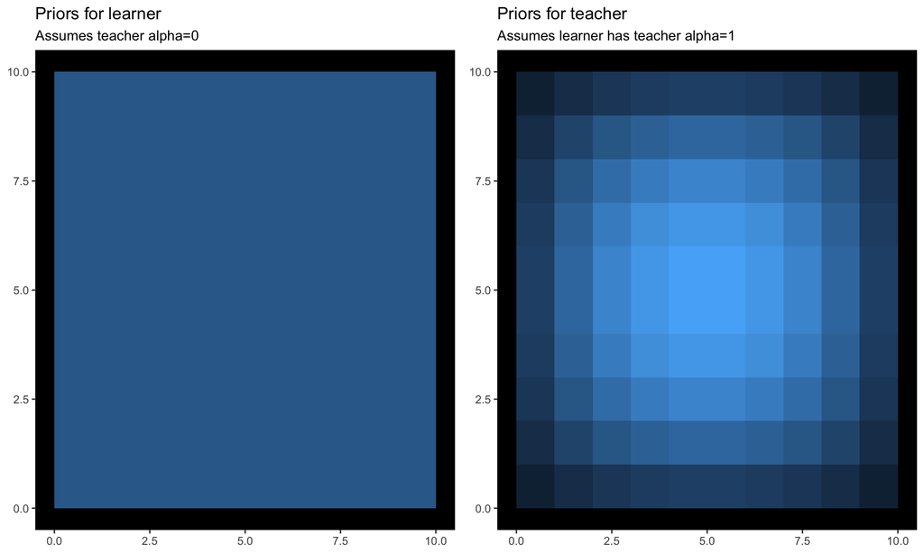

# The first data point

The teacher needs to decide what is the first point to sample. This leads to six things we need to calculate.

1. The sampling distribution over points the teacher generates. They do this by calculating what each point would do to the learner’s hypothesis distribution, based on their assumption about the learner’s alpha. Then, based on their alpha, they decide whether they want to make it more likely that the learner guesses the right hypothesis (tchAlpha > 0) or less (tchAlpha < 0) or if they don’t care (tchAlpha = 0).
2. The teacher then samples a point from that distribution, proportional to its probability.
3. The teacher then updates their estimate of what the learner’s distribution over hypotheses is, given that point.
4. The teacher then updates their estimate of what the learner’s distribution over points is (this will be useful later).
5. The learner updates their distribution over hypotheses, given that point.
6. The learner estimates their distribution over points.

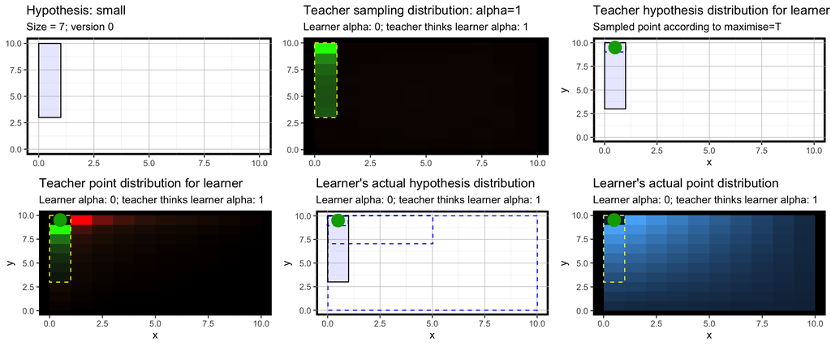

# The second data point

We’re going to do the same series of steps for the second data point, based on what was calculated earlier given the first.

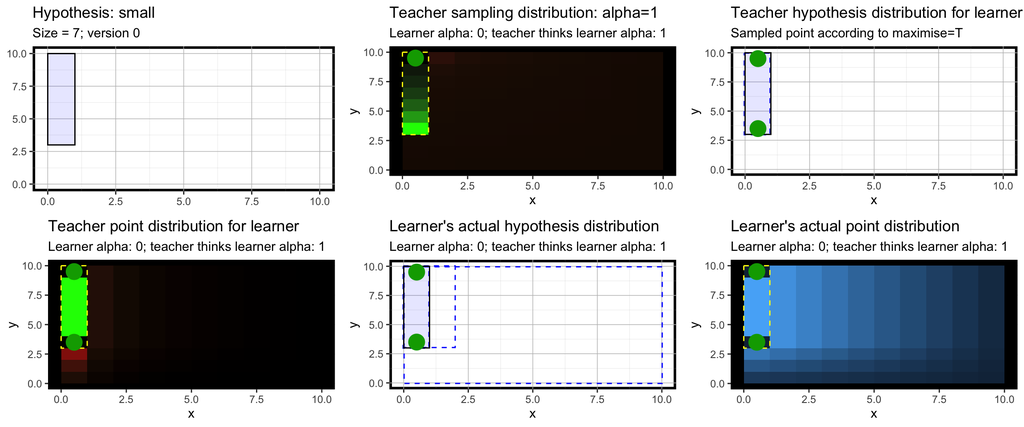

# The third data point

We’re going to do the same series of steps for the third data point, based on what was calculated earlier given the first and second.

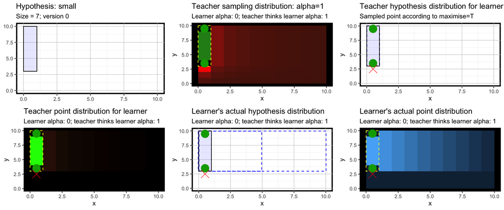

# The fourth data point

We’re going to do the same series of steps for the fourth data point, based on what was calculated earlier given the first, second, and third.

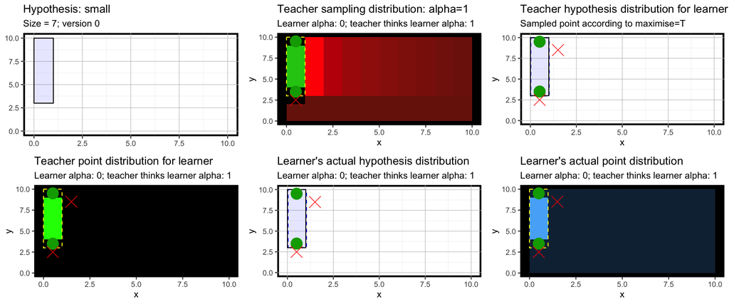

At the end, we save everything.